# Correlation

STAT 240 - Fall 2025

Robert Sholl

# Motivating Example

## Divorce

- Colorado has seen a large plummet in divorces over the past 2 decades
- What are they doing to produce such results?!

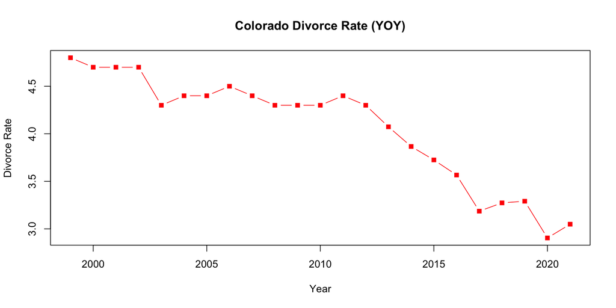

## Milk

- Colorado has also drastically reduced their cows milk consumption!

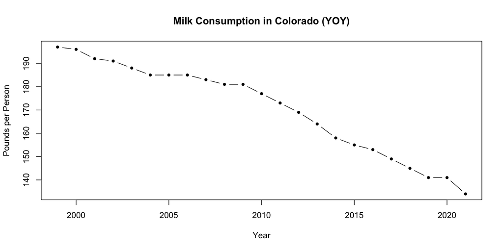

## The Solution

- Cow’s milk must cause divorce!

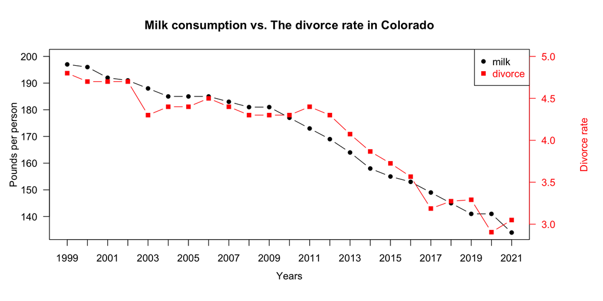

## Correlation

**Two or more variables that have some shared trend due to unknown causation or a shared cause**

[figure not shown]

# Correlation Analysis

## Scatterplots

$$\begin{aligned}
\text{Let } & X \equiv \{\text{Milk Consumption} \} \\
& Y \equiv \{ \text{Divorce Rate} \} \\
\\
& x_i = \text{pounds of milk consumed in year } i\\
& y_i = \text{divorce rate in year } i\\
\\
& (x_i,y_i) \text{ are an "ordered pair" from bivariate data} \\
& (x_1,y_1) , ... , (x_n,y_n) \text{ are coordinates on a graph}
\end{aligned}$$

## Scatterplots

**Linear association**: Two variables can be reasonably described with a line

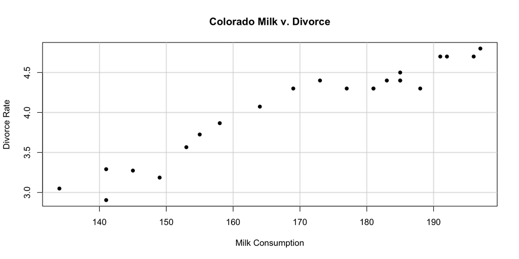

## Linear Associations

**Positive association**: larger values of one variable relate to larger values of another

**Strength of association**: the degree a linear association fits on a line

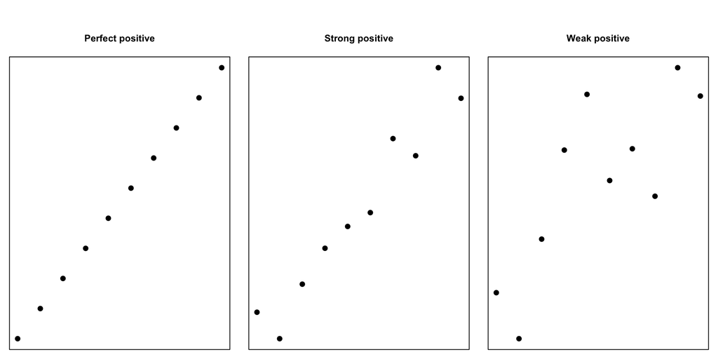

## Linear Association

**Negative association**: larger values of one variable related to smaller values of another

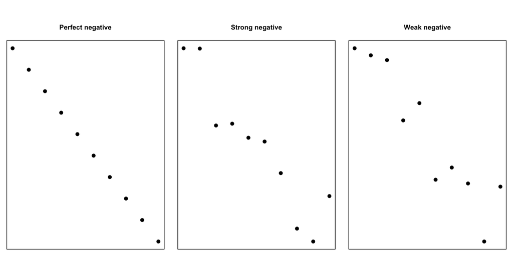

## Linear Association

When values are flatlined or not expressable with a line they’re referred to as “lacking association” or “nonlinear”

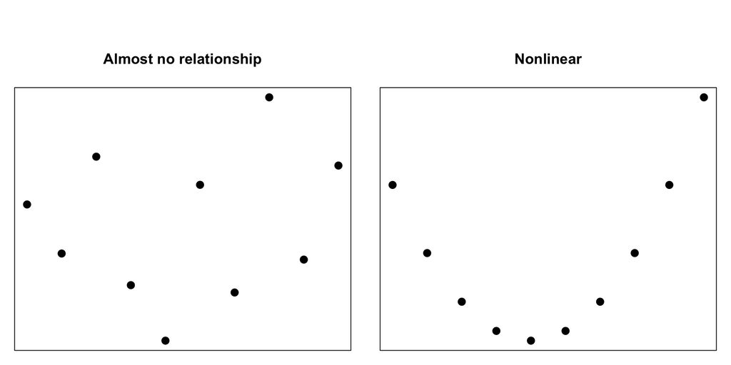

## Correlation Coefficient

- Quantification is more reliable than ‘gut’ labeling

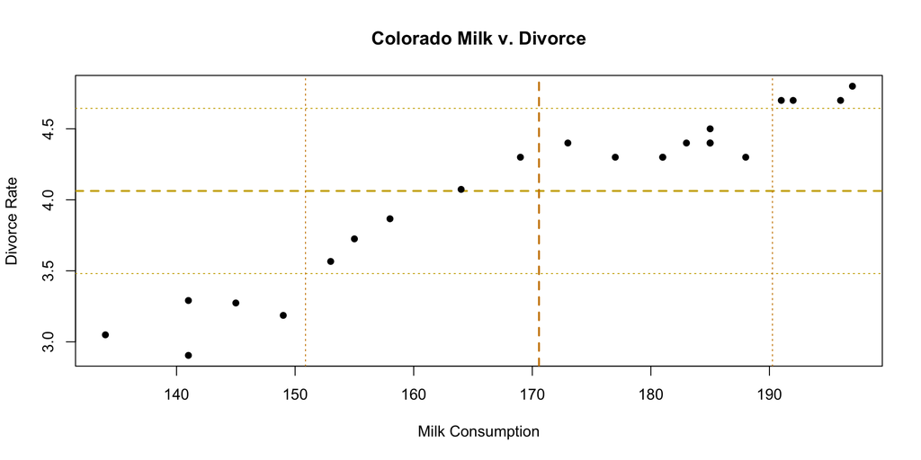

## Correlation Coefficient

$$z_{x,y} = \frac{(x,y)-(\bar x, \bar y)}{(s_x,s_y)}$$

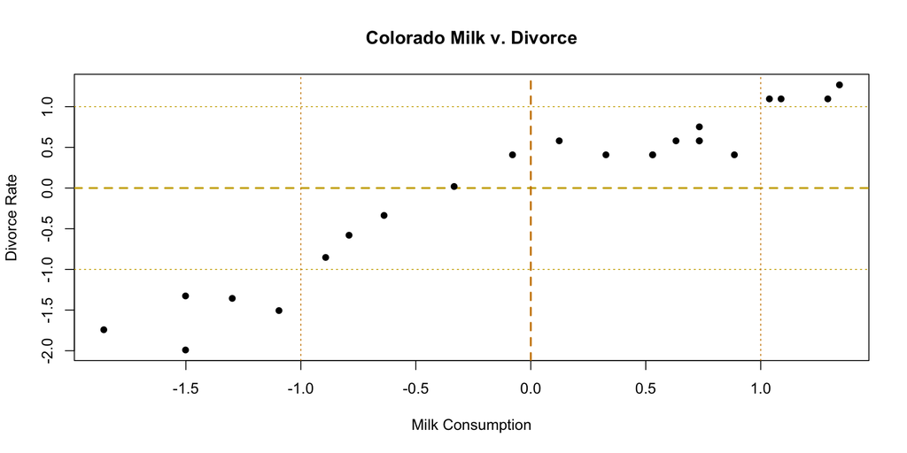

## Correlation Coefficient

$$\frac{\sum(z_x \times z_y)}{n-1}$$

$$r = \frac{1}{n-1}\sum_i \left(\frac{x_i - \bar x}{s_x} \right) \left(\frac{y_i - \bar y}{s_y} \right)$$

```r
# sample size
n = length(milk)

# z-score for milk consumption
z_x = (milk - mean(milk)) / sd(milk)

# z-score for divorce rate
z_y = (divorce - mean(divorce)) / sd(divorce)

# correlation coefficient for (x, y)
sum(z_x * z_y) / (n - 1)
```

```
[1] 0.9653682
```

## Correlation Coefficient

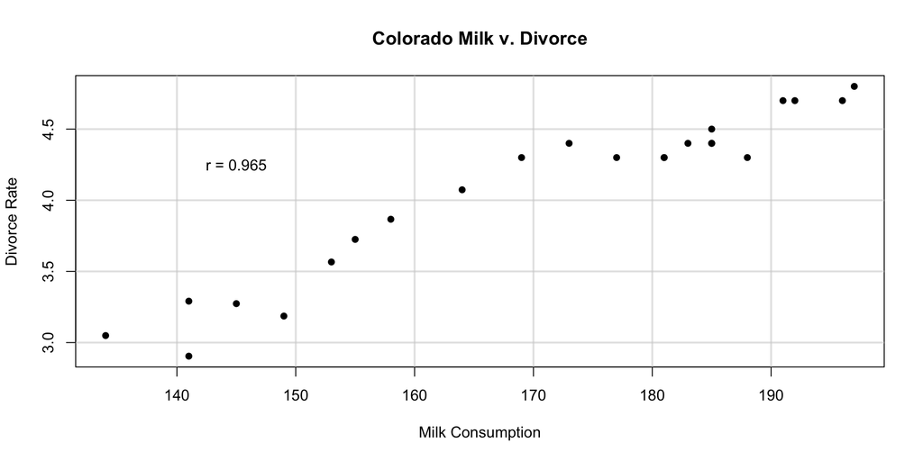

## Properties of $r$

1. The value is always between $-1 \le r \le 1$
- If $r = 1$, all of the data falls on a line with a positive slope
- If $r = -1$, all of the data falls on a line with a negative slope
- As $r \rightarrow 0$ the relationship between $x$ and $y$ weakens
- If $r=0$ no linear relationship exists
- As a rule of thumb, $-0.6<r<0.6$ is considered a weak relationship

## Properties of $r$

2. The correlation does not depend on unit of measure
3. Correlation is sensitive to outliers
4. Correlation cannot capture nonlinear relationships
- The formulation is strictly linear

## Boxplots

$$\begin{array}{|c|c|c|c|c|c|c|}
\hline
\text{Min} & \text{Q}_1 & \text{Median} & \text{Q}_3 & \text{Max} \\
\hline
134 & 154 & 177 & 185 & 197\\
\hline
\end{array}$$

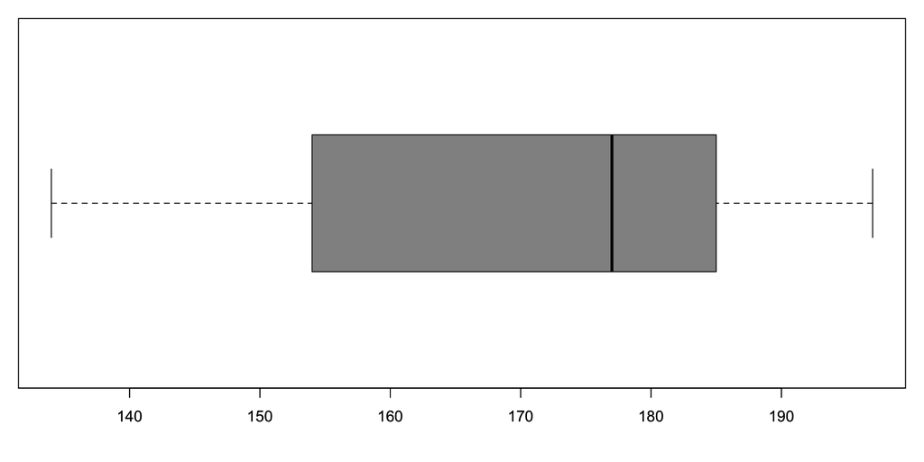

## Boxplots

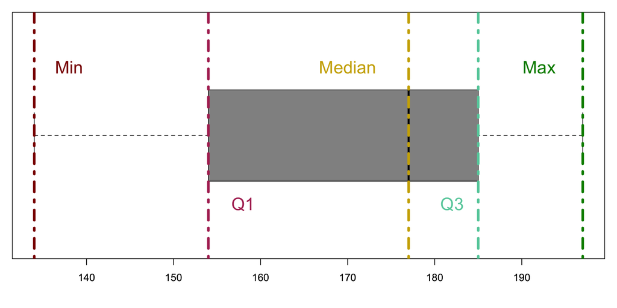

## Constucting a Boxplot

1. Find the 5 values in the five number summary
   1. Compute the IQR
   2. Find the upper & lower bounds for outliers
2. Draw a number line to represent the scale
3. Above the number line, draw a box with one end at $\text{Q}_1$ and the other at $\text{Q}_3$
   1. Draw a verticle line across the box at the **median**

## Constructing a Boxplot

4. Draw horizontal lines (“whiskers”) from the box to the smallest and largest values within the upper & lower outlier bounds
5. Plot observations outside the bounds with a “star” (*) to identify them as outliers

## Skewness

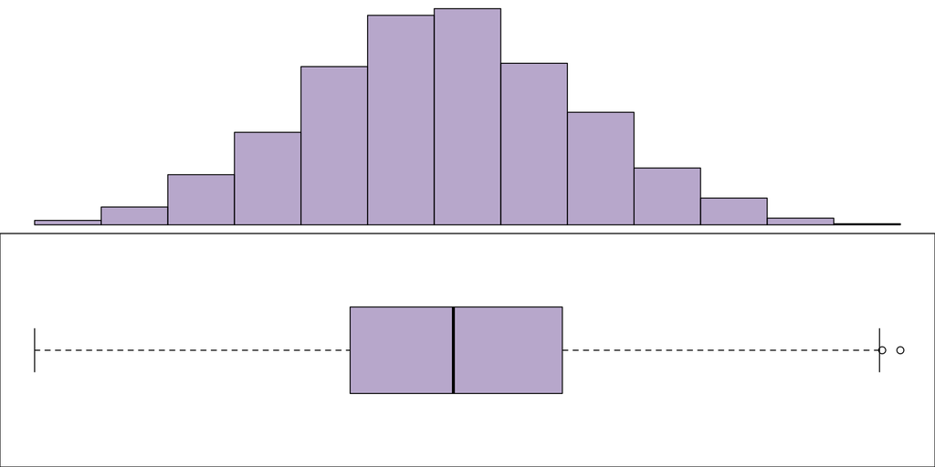

## Spurious Correlation

- Correlation doesn’t depend on unit of measure
  - It also can’t consider them
  - What other variable do $x$ and $y$ change with?

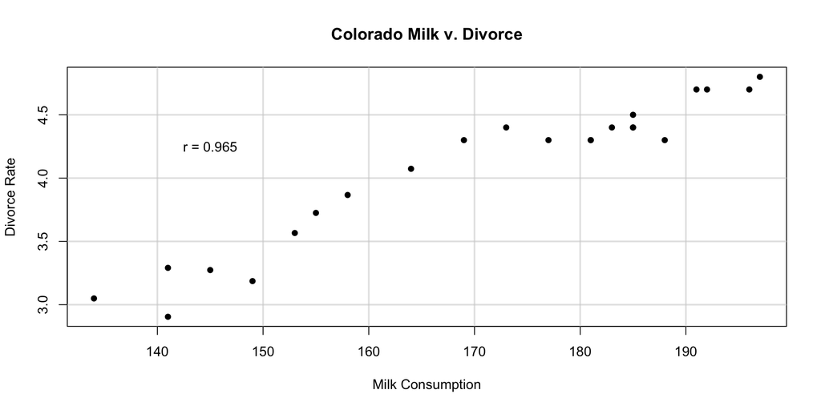

## Comparative Boxplots

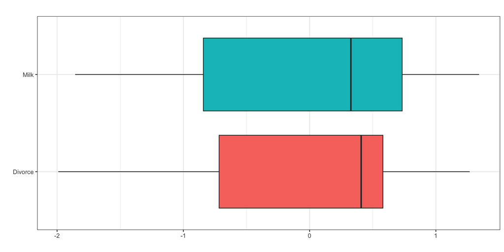

## Correlation v. Causation

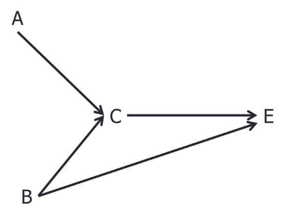